# Lab3

Priya Shaji

2/18/2019

## The Normal Distribution

### The data

download the data

```r
download.file("http://www.openintro.org/stat/data/bdims.RData", destfile = "bdims.RData")
```

load the data

```r
load("bdims.RData")
```

```r
head(bdims)
```

```
##   bia.di bii.di bit.di che.de che.di elb.di wri.di kne.di ank.di sho.gi
## 1   42.9   26.0   31.5   17.7   28.0   13.1   10.4   18.8   14.1  106.2
## 2   43.7   28.5   33.5   16.9   30.8   14.0   11.8   20.6   15.1  110.5
## 3   40.1   28.2   33.3   20.9   31.7   13.9   10.9   19.7   14.1  115.1
## 4   44.3   29.9   34.0   18.4   28.2   13.9   11.2   20.9   15.0  104.5
## 5   42.5   29.9   34.0   21.5   29.4   15.2   11.6   20.7   14.9  107.5
## 6   43.3   27.0   31.5   19.6   31.3   14.0   11.5   18.8   13.9  119.8
##   che.gi wai.gi nav.gi hip.gi thi.gi bic.gi for.gi kne.gi cal.gi ank.gi
## 1   89.5   71.5   74.5   93.5   51.5   32.5   26.0   34.5   36.5   23.5
## 2   97.0   79.0   86.5   94.8   51.5   34.4   28.0   36.5   37.5   24.5
## 3   97.5   83.2   82.9   95.0   57.3   33.4   28.8   37.0   37.3   21.9
## 4   97.0   77.8   78.8   94.0   53.0   31.0   26.2   37.0   34.8   23.0
## 5   97.5   80.0   82.5   98.5   55.4   32.0   28.4   37.7   38.6   24.4
## 6   99.9   82.5   80.1   95.3   57.5   33.0   28.0   36.6   36.1   23.5
##   wri.gi age  wgt   hgt sex
## 1   16.5  21 65.6 174.0   1
## 2   17.0  23 71.8 175.3   1
## 3   16.9  28 80.7 193.5   1
## 4   16.6  23 72.6 186.5   1
## 5   18.0  22 78.8 187.2   1
## 6   16.9  21 74.8 181.5   1
```

```r
mdims <- subset(bdims, sex == 1)
fdims <- subset(bdims, sex == 0)
```

The normal distribution analysis

creating density histograms

```r
fhgtmean <- mean(fdims$hgt)
fhgtsd   <- sd(fdims$hgt)
```

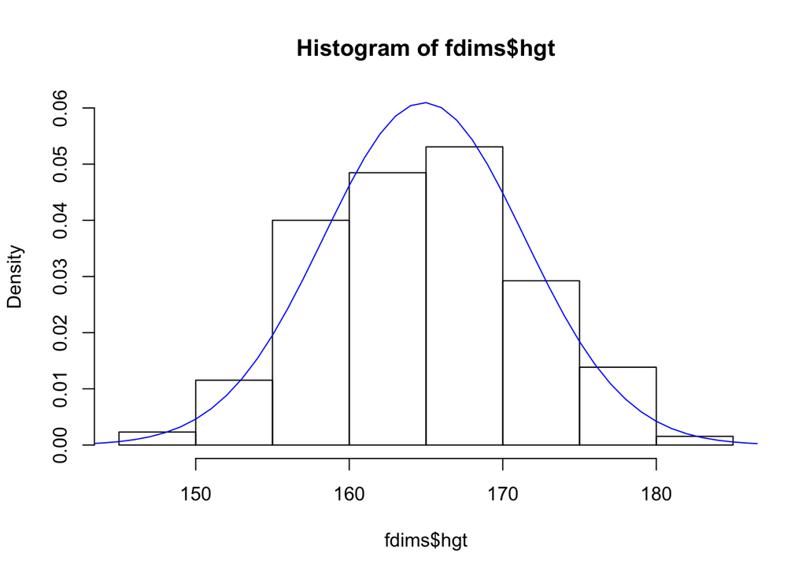

```r
hist(fdims$hgt, probability = TRUE,ylim = c(0, 0.06))
x <- 140:190
y <- dnorm(x = x, mean = fhgtmean, sd = fhgtsd)
lines(x = x, y = y, col = "blue")
```

```r
fhgtmean <- mean(fdims$hgt)
fhgtsd   <- sd(fdims$hgt)
```

Evaluating the normal distribution

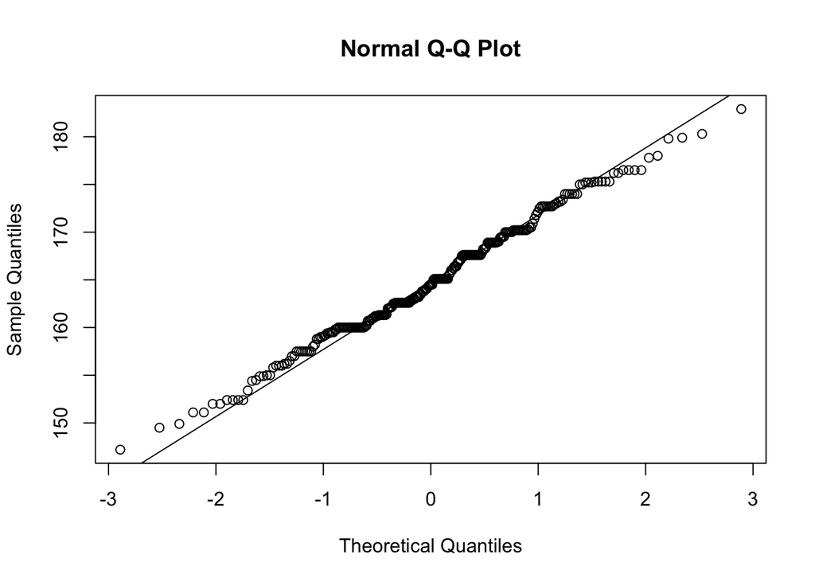

```r
qqnorm(fdims$hgt)
qqline(fdims$hgt)
```

```r
sim_norm <- rnorm(n = length(fdims$hgt), mean = fhgtmean, sd = fhgtsd)
sim_norm
```

```
##   [1] 189.1323 156.5018 163.8752 165.6349 172.7249 157.8723 164.9861
##   [8] 161.0876 169.5002 169.8463 170.4260 165.5267 161.9198 159.9991
##  [15] 160.5634 164.3173 176.2616 165.0047 171.6235 163.2474 170.2342
##  [22] 162.6041 161.7901 168.5107 172.1545 157.5391 160.8772 165.5507
##  [29] 167.6417 155.1977 166.9333 169.0549 163.5563 156.6540 165.2283
##  [36] 171.8389 167.3599 164.6341 165.7681 163.5555 162.7846 172.2757
##  [43] 162.5045 172.6246 149.3478 165.2738 176.7649 168.1759 164.3292
##  [50] 162.7630 151.7325 166.3579 173.1490 156.7207 169.2578 159.8083
##  [57] 170.9324 168.8489 165.4776 165.2993 162.7761 155.5681 161.6675
##  [64] 165.9991 164.7768 161.3783 161.1708 164.2357 158.2069 165.4356
##  [71] 162.1022 163.6637 173.0466 156.3689 181.5810 177.9489 176.9943
##  [78] 158.9838 168.4945 168.1853 168.7934 164.3525 173.1001 163.3432
##  [85] 159.4191 165.8890 175.1964 161.0112 162.1965 157.6935 160.5827
##  [92] 171.7059 159.5325 164.8785 154.0501 154.0733 170.0363 173.9859
##  [99] 166.4474 163.2905 162.4192 169.2360 157.7405 161.2321 158.7740
```

[output cut: 23 more lines]

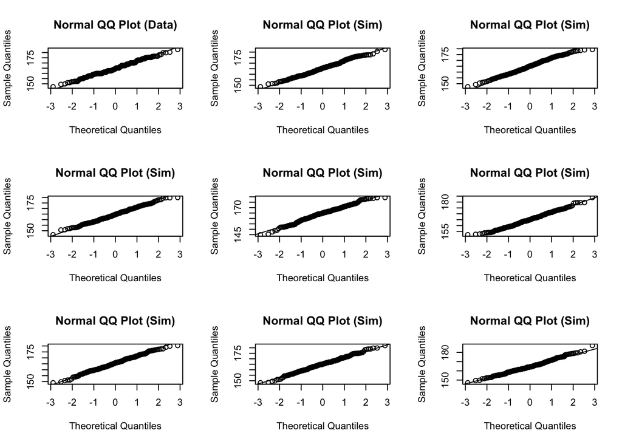

```r
qqnormsim(fdims$hgt)
```

Normal probabilities

```r
1 - pnorm(q = 182, mean = fhgtmean, sd = fhgtsd)
```

```
## [1] 0.004434387
```

```r
sum(fdims$hgt > 182) / length(fdims$hgt)
```

```
## [1] 0.003846154
```

### Exercises

#### Exercise 1

Make a histogram of men’s heights and a histogram of women’s heights. How would you compare the various aspects of the two distributions?

Answer 1

Men’s Height Histogram

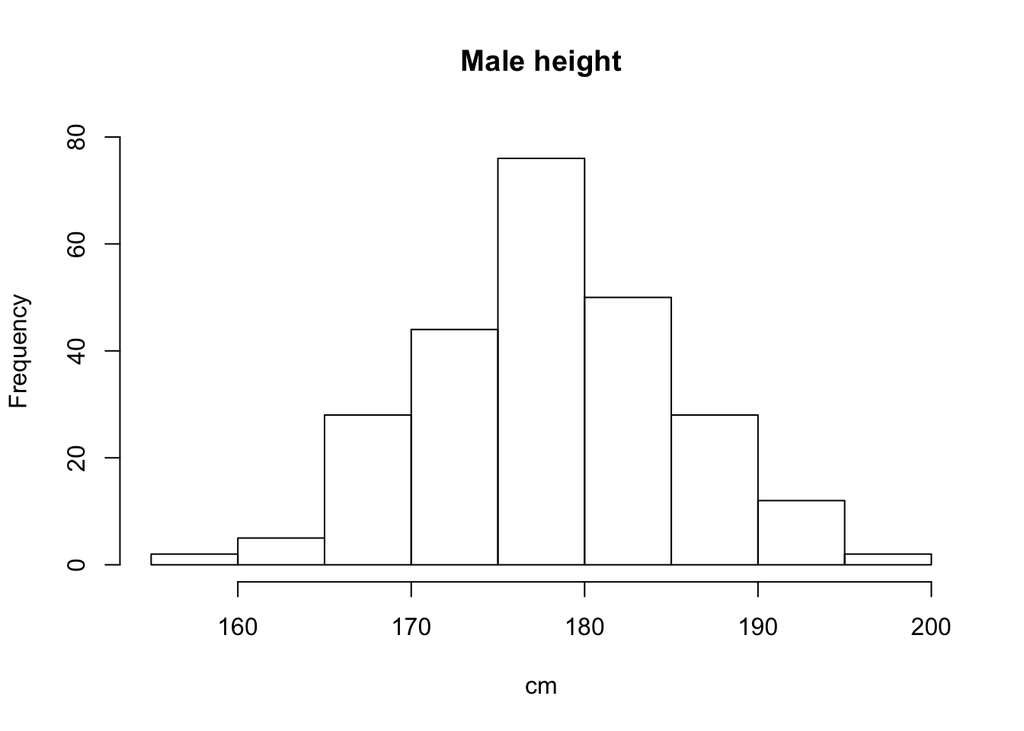

```r
hist(mdims$hgt, main="Male height", xlab="cm", ylim = c(0, 80))
```

Women’s Height Histogram

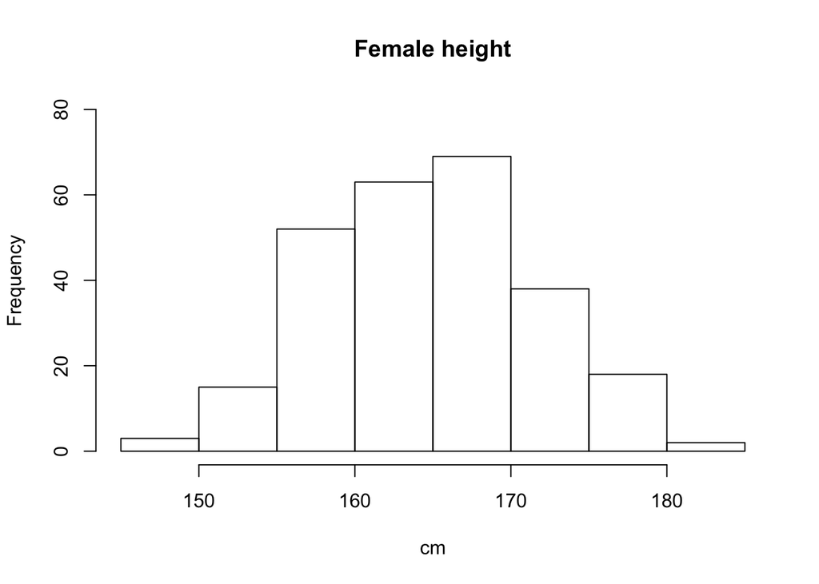

```r
hist(fdims$hgt, main="Female height", xlab="cm", ylim = c(0, 80))
```

#### Exercise 2

Based on the this plot, does it appear that the data follow a nearly normal distribution?

Answer 2

Yes, It looks like the data follows a nearly normal distribution

#### Exercise 3

Make a normal probability plot of sim_norm. Do all of the points fall on the line? How does this plot compare to the probability plot for the real data?

Answer 3

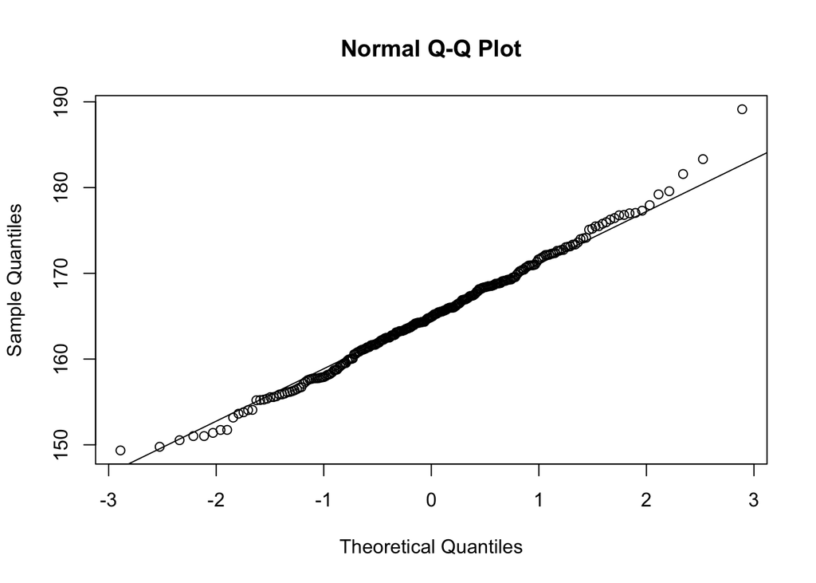

```r
qqnorm(sim_norm)
qqline(sim_norm)
```

Yes, It seems like the data follows nearly normal distribution.The points are close to the line or the points are close to the real data.

#### Exercise 4

Does the normal probability plot for fdims$hgt look similar to the plots created for the simulated data? That is, do plots provide evidence that the female heights are nearly normal?

Answer 4

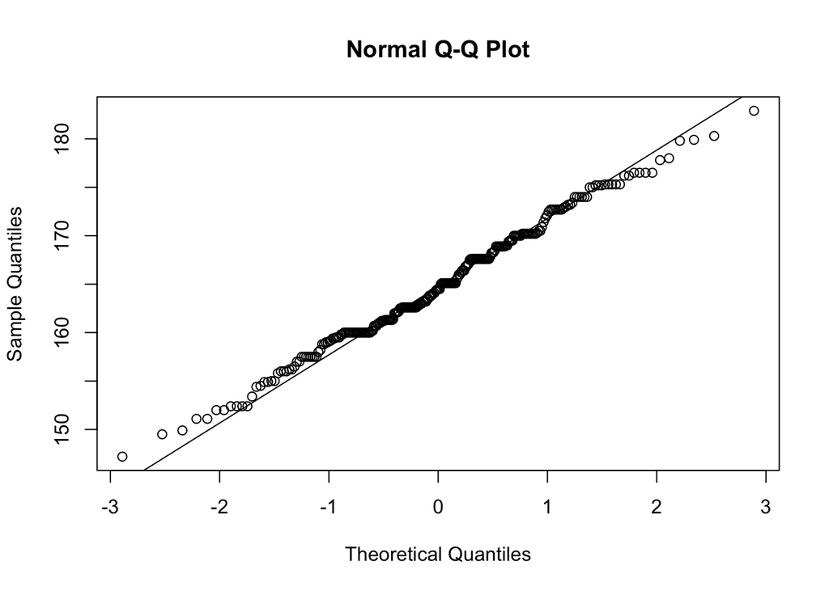

```r
qqnorm(fdims$hgt)
qqline(fdims$hgt)
```

These plots are most likely similar. There are few variations along the y axis , though not much off as to think the distributions are not normal.

#### Exercise 5

Using the same technique, determine whether or not female weights appear to come from a normal distribution.

Answer 5

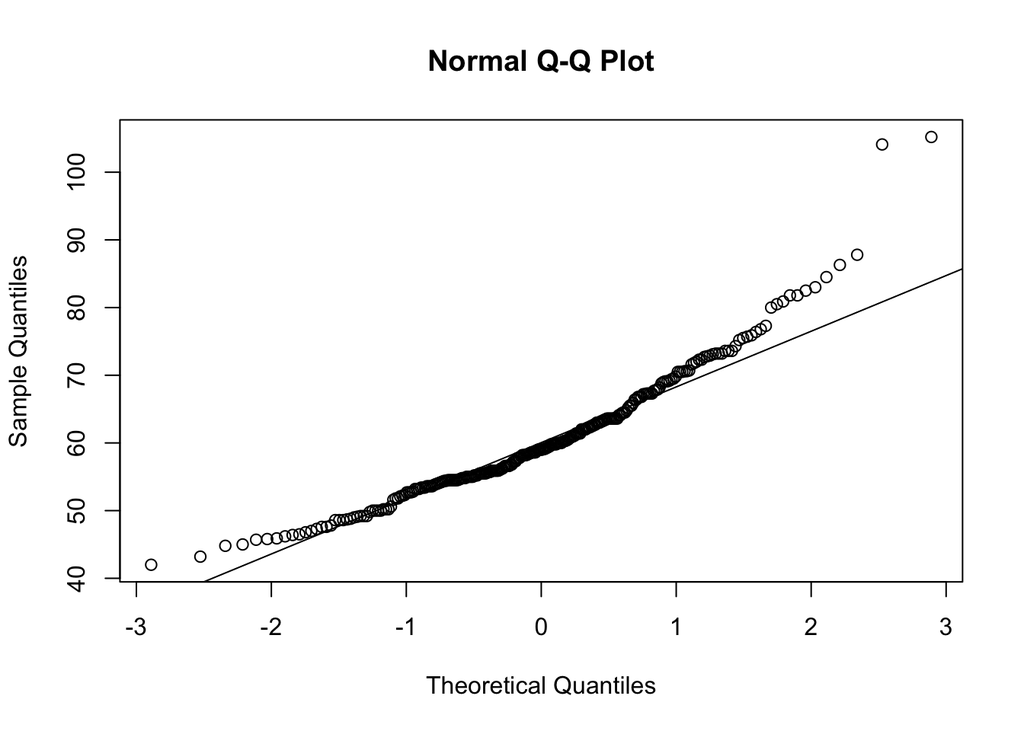

```r
qqnorm(fdims$wgt)
qqline(fdims$wgt)
```

The distribution for weight is right skewed . The Q-Q plot for the real data diverges from the line. Therefore the distribution does not seem normal.

#### Exercise 6

Write out two probability questions that you would like to answer; one regarding female heights and one regarding female weights. Calculate the those probabilities using both the theoretical normal distribution as well as the empirical distribution (four probabilities in all). Which variable, height or weight, had a closer agreement between the two methods?

Answer 6

Q: What is the probability that a random chosen young adult female is shorter than 170 cm?

```r
pnorm(q = 170, mean = fhgtmean, sd = fhgtsd)
```

```
## [1] 0.7833331
```

```r
sum(fdims$hgt < 170) / length(fdims$hgt)
```

```
## [1] 0.7538462
```

Q: Whats the probability that a female weighs less that 50kg?

```r
fwgtmean <- mean(fdims$wgt)
fwgtsd   <- sd(fdims$wgt)
pnorm(q=50,mean=fwgtmean,sd=fwgtsd)
```

```
## [1] 0.135143
```

```r
sum(fdims$wgt < 50) / length(fdims$wgt)
```

```
## [1] 0.1038462
```

Generally, height is closer

### On Your Own

#### Ques_1

1: Now let’s consider some of the other variables in the body dimensions data set. Using the figures at the end of the exercises, match the histogram to its normal probability plot. All of the variables have been standardized (first subtract the mean, then divide by the standard deviation), so the units won’t be of any help. If you are uncertain based on these figures, generate the plots in R to check.

Answer 1

1. The histogram for female biiliac (pelvic) diameter (“bii.di”) belongs to normal probability plot letter:

PLOT B

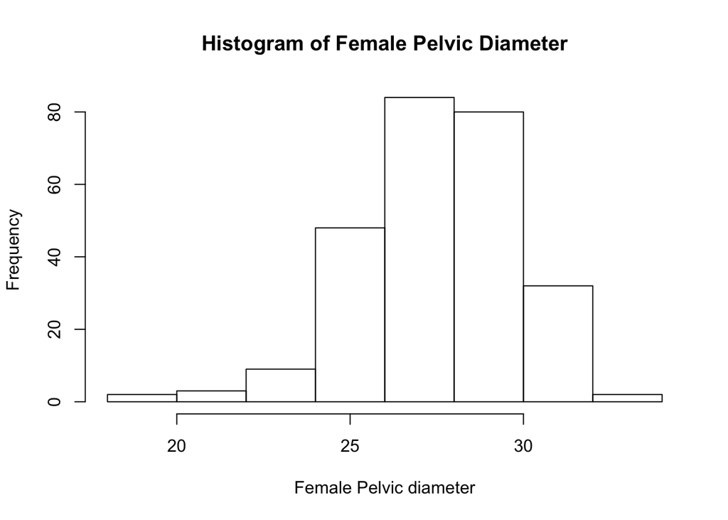

```r
hist(fdims$bii.di,xlab = "Female Pelvic diameter", main = "Histogram of Female Pelvic Diameter")
```

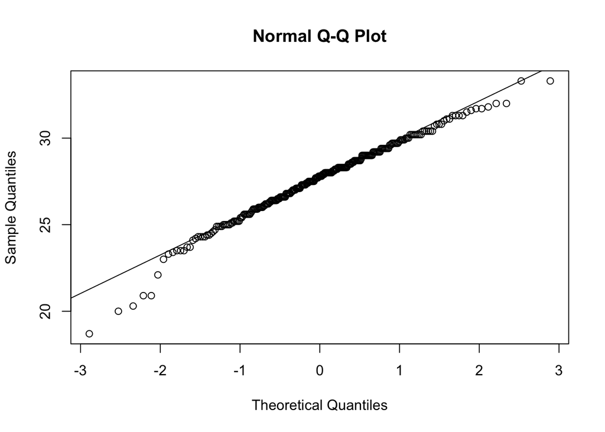

```r
qqnorm(fdims$bii.di)
qqline(fdims$bii.di)
```

2. The histogram for female elbow diameter (elb.di) belongs to normal probability plot letter ____.

PLOT C

[figure not shown]

```r
hist(bdims$elb.di,xlab = "Female elbow diameter", main = "Histogram of Female Elbow Diameter")
```

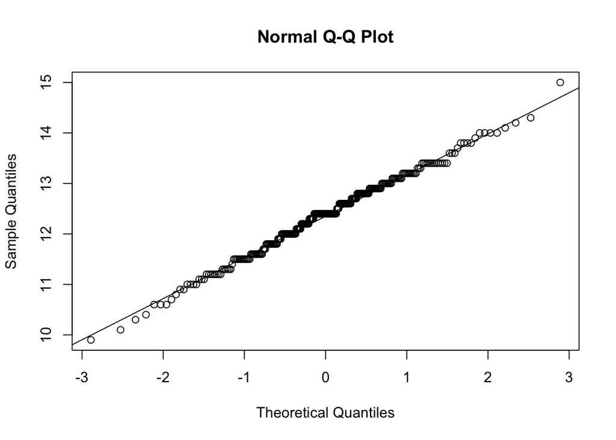

```r
qqnorm(fdims$elb.di)
qqline(fdims$elb.di)
```

3. The histogram for general age (age) belongs to normal probability plot letter ____.

PLOT D

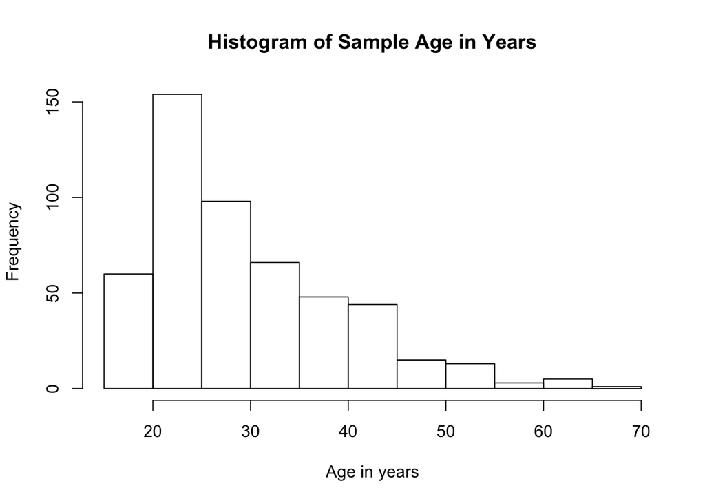

```r
hist(bdims$age, xlab = "Age in years", main = "Histogram of Sample Age in Years")
```

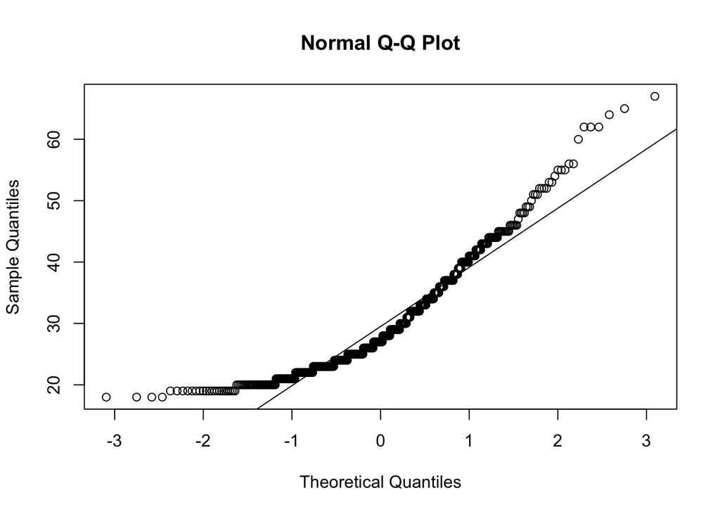

```r
qqnorm(bdims$age)
qqline(bdims$age)
```

4. The histogram for female chest depth (che.de) belongs to normal probability plot letter ____.

PLOT A

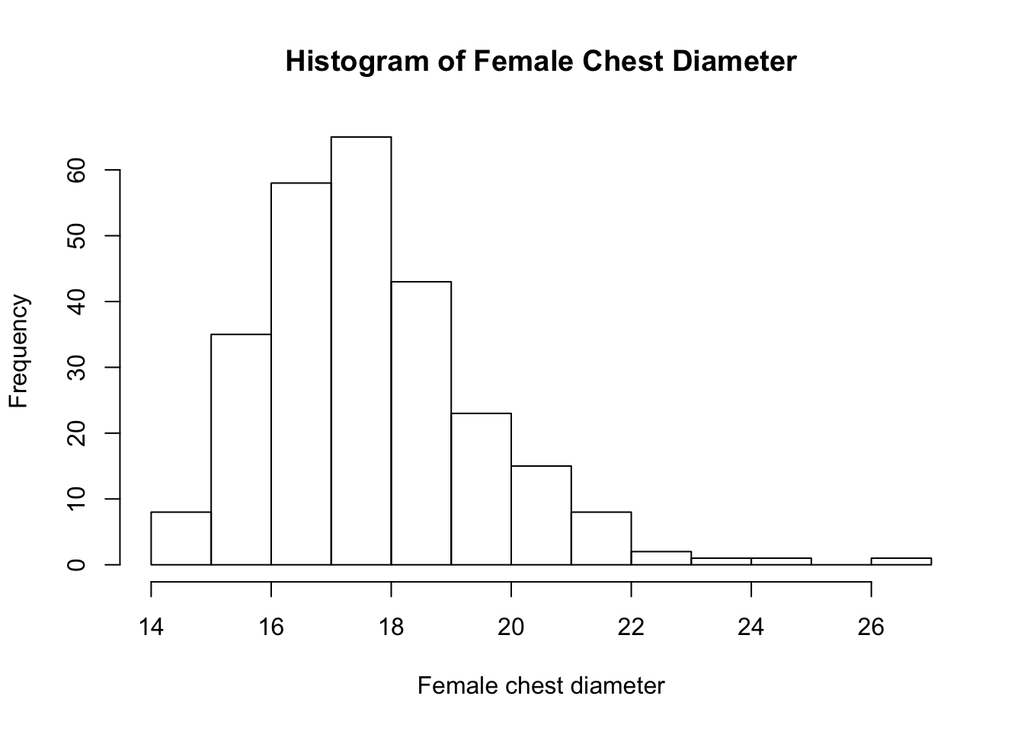

```r
hist(fdims$che.de,xlab = "Female chest diameter", main = "Histogram of Female Chest Diameter")
```

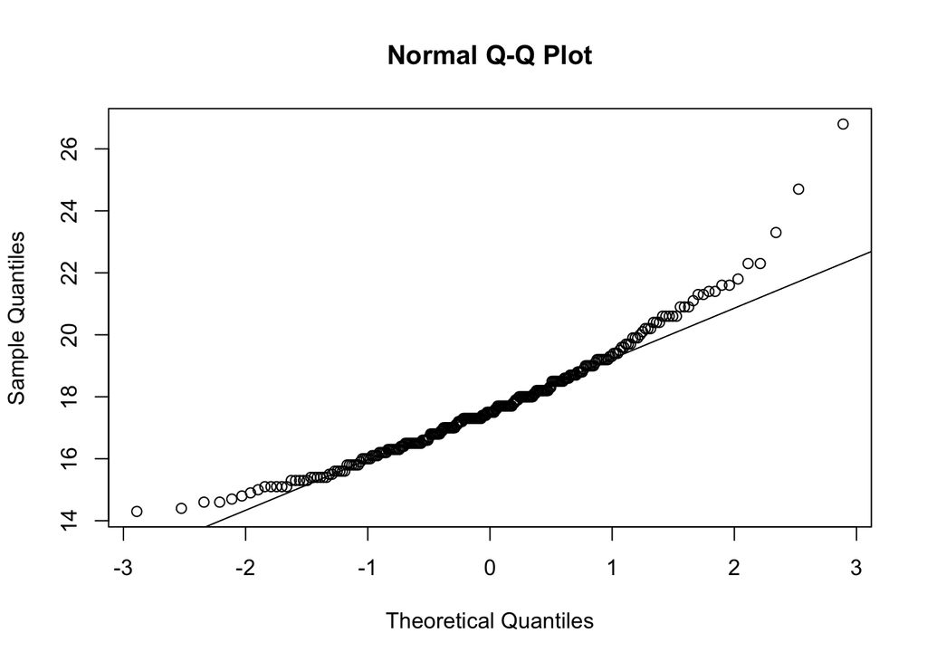

```r
qqnorm(fdims$che.de)
qqline(fdims$che.de)
```